# Проверка статистических гипотез

Морские моллюски: набор данных Abalone

## Требования к сдаче и оформлению задания

Заполните этот qmd-файл кодом и ответами. Порядок сдачи задания описан в README.md, в Google Classroom или на Stepik.

1. Старайтесь соблюдать единый стиль оформления и структуру отчёта. Не оставляйте лишние чанки кода, текст или комментарии, которые не относятся к решению задания.
2. Численные результаты представляйте в тексте или аккуратных таблицах с понятными подписями. Не оставляйте необработанный консольный вывод или отдельные числа без пояснений.
3. Графики должны быть достаточно крупными, с читаемыми русскими подписями, содержательным заголовком и правильно названными осями. Не используйте фон ggplot2 по умолчанию.
4. Ответы на вопросы и интерпретации результатов, включая графики, пишите обычным текстом, а не комментариями к коду. Код и его вывод не заменяют ответ на вопрос.
5. Сохраняйте исходную структуру проекта в репозитории. Не добавляйте лишние файлы, которые не относятся к проекту или выполнению заданий.
6. Оформление коммитов и веток на GitHub должно соответствовать общим правилам для всех курсов Института биоинформатики.

## О задании

- В этом домашнем задании мы будем использовать набор данных **Abalone**, содержащий измерения 4177 морских моллюсков рода *Haliotis*: [Подробнее](https://archive.ics.uci.edu/dataset/1/abalone).
- Вам предстоит проверить три статистические гипотезы: **две – с помощью доверительных интервалов (ДИ), одну – с помощью сравнения тестовой статистики с критическим значением**.
- Во всех заданиях используйте **уровень значимости $\alpha = 0.05$**. Для построения ДИ используйте **95%-й уровень доверия**.
- **Формулируйте выводы в терминах нулевой гипотезы**: мы отклоняем или не отклоняем именно её!

## О данных

Файл `abalone.csv` в директории `data` содержит несколько столбцов-признаков, из которых нам потребуются:

- **`Sex`**: `M` – самцы, `F` – самки, `I` – незрелые особи.
- **`Length`** – длина раковины, мм
- **`Shucked_weight`** – масса съедобной части моллюска после извлечения из раковины, г
- **`Shell_weight`** – масса высушенной раковины, г

## Загрузка и подготовка данных

Загрузите данные и оцените, требуется ли подготовка данных для анализа. Все ли признаки нужного типа?

```r
abalone <- read.csv("data/abalone.csv")

str(abalone)
```

```
'data.frame':   4177 obs. of  9 variables:
 $ Sex           : chr  "M" "M" "F" "M" ...
 $ Length        : int  91 70 106 88 66 85 106 109 95 110 ...
 $ Diameter      : int  73 53 84 73 51 60 83 85 74 88 ...
 $ Height        : int  19 18 27 25 16 19 30 25 25 30 ...
 $ Whole_weight  : num  102.8 45.1 135.4 103.2 41 ...
 $ Shucked_weight: num  44.9 19.9 51.3 43.1 17.9 28.2 47.4 58.8 43.3 62.9 ...
 $ Viscera_weight: num  20.2 9.7 28.3 22.8 7.9 15.5 28.3 29.9 22.5 30.2 ...
 $ Shell_weight  : num  30 14 42 31 11 24 66 52 33 64 ...
 $ Rings         : int  15 7 9 10 7 8 20 16 9 19 ...
```

```r
colSums(is.na(abalone))
```

```
           Sex         Length       Diameter         Height   Whole_weight
             0              0              0              0              0
Shucked_weight Viscera_weight   Shell_weight          Rings
             0              0              0              0
```

```r
sapply(abalone[, c("Sex", "Length",
                   "Shucked_weight", "Shell_weight")], class)
```

```
           Sex         Length Shucked_weight   Shell_weight
   "character"      "integer"      "numeric"      "numeric"
```

## 1. Сравнение длины раковины самцов и самок

Исследователи хотят сравнить длину раковины самцов и самок. Вопрос исследования: **различается ли средняя длина раковины в популяциях самцов и самок?**

### Задание 1.1

Сформулируйте нулевую и альтернативную гипотезы. Какой параметр генеральной совокупности вы оцениваете?

- $H_0$: Средняя длина раковины самок равна средней длине раковины самцов
- $H_a$: Средняя длина раковины самок не равна средней длине раковины самцов

### Задание 1.2

Выберите и рассчитайте описательные статистики, необходимые для исследования вопроса.

Визуализируйте распределения исследуемого признака у самцов и самок. Кратко опишите особенности распределений. Предположите по графикам, различается ли средняя длина раковины между сравниваемыми группами.

```r
stats <- data.frame(
  Пол = c("Самки", "Самцы"),
  Количество = c(
    sum(abalone$Sex == "F"),
    sum(abalone$Sex == "M")
  ),
  Среднее = c(
    mean(abalone$Length[abalone$Sex == "F"]),
    mean(abalone$Length[abalone$Sex == "M"])
  ),
  Медиана = c(
    median(abalone$Length[abalone$Sex == "F"]),
    median(abalone$Length[abalone$Sex == "M"])
  ),
  Стандартное_отклонение = c(
    sd(abalone$Length[abalone$Sex == "F"]),
    sd(abalone$Length[abalone$Sex == "M"])
  )
)

knitr::kable(
  stats,
  digits = 3,
  caption = "Описательные статистики длины раковины самцов и самок"
)
```

Описательные статистики длины раковины самцов и самок

| Пол | Количество | Среднее | Медиана | Стандартное_отклонение |
| --- | --- | --- | --- | --- |
| Самки | 1307 | 115.819 | 118 | 17.232 |
| Самцы | 1528 | 112.278 | 116 | 20.539 |

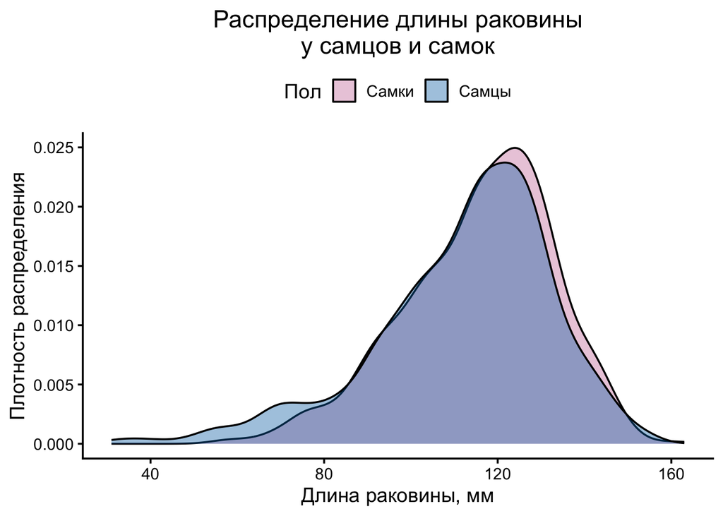

```r
length_data <- subset(abalone, Sex %in% c("M", "F"))

ggplot(length_data, aes(x = Length, fill = Sex)) +
  geom_density(alpha = 0.4) +
  scale_fill_manual(
    values = c("F" = "#CC79A7", "M" = "#0072B2"),
    labels = c("F" = "Самки", "M" = "Самцы")
  ) +
  labs(
    title = "Распределение длины раковины\nу самцов и самок",
    x = "Длина раковины, мм",
    y = "Плотность распределения",
    fill = "Пол"
  ) +
  theme_classic(base_size = 14) +
  theme(
    plot.title = element_text(hjust = 0.5),
    legend.position = "top"
  )
```

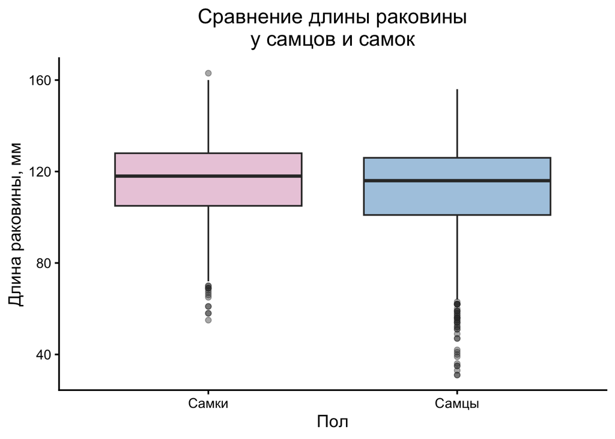

```r
ggplot(length_data, aes(x = Sex, y = Length, fill = Sex)) +
  geom_boxplot(alpha = 0.4) +
  scale_fill_manual(
    values = c("F" = "#CC79A7", "M" = "#0072B2"),
    labels = c("F" = "Самки", "M" = "Самцы")
  ) +
  scale_x_discrete(
    labels = c("F" = "Самки", "M" = "Самцы")
  ) +
  labs(
    title = "Сравнение длины раковины\nу самцов и самок",
    x = "Пол",
    y = "Длина раковины, мм"
  ) +
  theme_classic(base_size = 14) +
  theme(
    plot.title = element_text(hjust = 0.5),
    legend.position = "none"
  )
```

### Задание 1.3

Выберите подходящий тип доверительного интервала и объясните, почему он соответствует исследовательскому вопросу.

По моему мнению подходит доверительный интервал Уэлча (95% доверительный интервал), так как группы независимы, проверяем разность средних, и метод не требует равенства дисперсий генеральных совокупностей. …..

### Задание 1.4

Постройте выбранный доверительный интервал для проверки поставленной гипотезы

```r
ci <- t.test(
  Length ~ Sex,
  data = subset(abalone, Sex %in% c("M", "F")),
  conf.level = 0.95
)

ci$p.value
```

```
[1] 6.380151e-07
```

```r
ci$conf.int
```

```
[1] 2.149486 4.931569
attr(,"conf.level")
[1] 0.95
```

### Задание 1.5

На основании доверительного интервала проверьте сформулированную гипотезу. Объясните результат и решение.

Значения доверительного интервала положительные и не содержат 0 (2.149486 4.931569) - на уровне значимости 0,05 отклоняем нулевую гипотезу - средняя длина раковин самок большое средней длины самцов. ……

Что можно сказать о направлении и величине различия? Совпадает ли результат с вашим впечатлением от графика в задании 1.2? Как вы думаете, почему?

Графики сильно перекрываются, но рапределение для самок смещено вправо - их распределение длины имеет большие значения. Это совпадает с тестом доверительного интервала - средняя длина раковин самок больше, чем у самцов на 3,54 мм (mean(abalone$Length[abalone$Sex == “F”]) - mean(abalone$Length[abalone$Sex == “F”])). Но различие не велико тк кривые во многом совпадают. Однако даже небольшое различие средних может быть статистически значимым для большой выборки. ……

## 2. Сравнение массы съедобной части моллюска у самцов и самок

Исследователи предположили, что средняя масса съедобной части моллюска у самцов **больше**, чем у самок. Проверьте это предположение.

### Задание 2.1

Укажите, какой параметр генеральной совокупности вы оцениваете. Сформулируйте нулевую и альтернативную гипотезы.

> Обратите внимание на порядок вычитания средних: он определяет знак разности и её интерпретацию.

Разность средних масс съедобной части молюска ($\mu$(самцы) - $\mu$(самки))

- $H_0$: $\mu$(самцы) - $\mu$(самки) = 0
- $H_a$: $\mu$(самцы) - $\mu$(самки) > 0

### Задание 2.2

Выберите и рассчитайте описательные статистики, необходимые для исследования вопроса.

Визуализируйте распределения исследуемого признака у самцов и самок. Кратко опишите особенности распределений. Предположите по графикам, больше ли средняя масса съедобной части моллюска у самцов, чем у самок.

```r
weight_data <- subset(abalone, Sex %in% c("M", "F"))

stats_weight <- data.frame(
  Пол = c("Самки", "Самцы"),
  Количество = c(
    sum(weight_data$Sex == "F"),
    sum(weight_data$Sex == "M")
  ),
  Среднее = c(
    mean(weight_data$Shucked_weight[weight_data$Sex == "F"]),
    mean(weight_data$Shucked_weight[weight_data$Sex == "M"])
  ),
  Медиана = c(
    median(weight_data$Shucked_weight[weight_data$Sex == "F"]),
    median(weight_data$Shucked_weight[weight_data$Sex == "M"])
  ),
  Стандартное_отклонение = c(
    sd(weight_data$Shucked_weight[weight_data$Sex == "F"]),
    sd(weight_data$Shucked_weight[weight_data$Sex == "M"])
  )
)

knitr::kable(
  stats_weight,
  digits = 3,
  caption = "Описательные статистики массы съедобной части у самцов и самок"
)
```

Описательные статистики массы съедобной части у самцов и самок

| Пол | Количество | Среднее | Медиана | Стандартное_отклонение |
| --- | --- | --- | --- | --- |
| Самки | 1307 | 89.238 | 88.10 | 39.733 |
| Самцы | 1528 | 86.589 | 84.35 | 44.600 |

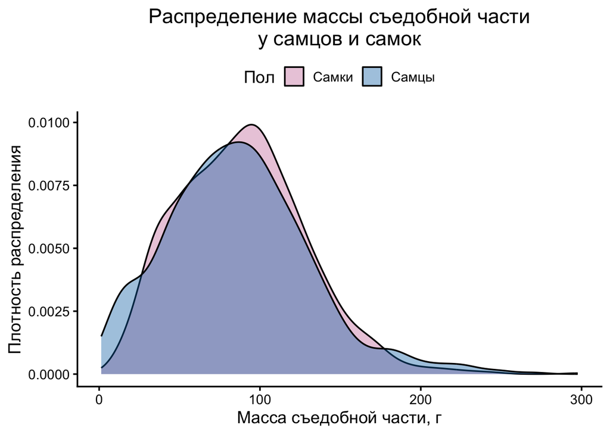

```r
ggplot(weight_data, aes(x = Shucked_weight, fill = Sex)) +
  geom_density(alpha = 0.4) +
  scale_fill_manual(
    values = c("F" = "#CC79A7", "M" = "#0072B2"),
    labels = c("F" = "Самки", "M" = "Самцы")
  ) +
  labs(
    title = "Распределение массы съедобной части\nу самцов и самок",
    x = "Масса съедобной части, г",
    y = "Плотность распределения",
    fill = "Пол"
  ) +
  theme_classic(base_size = 14) +
  theme(
    plot.title = element_text(hjust = 0.5),
    legend.position = "top"
  )
```

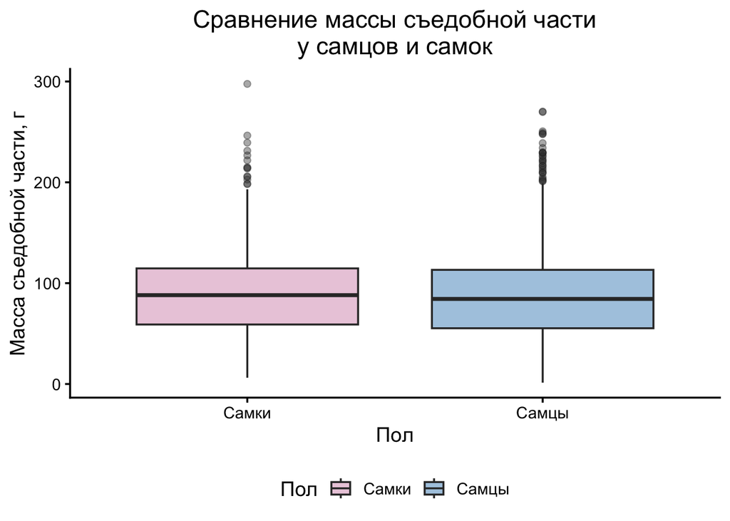

```r
ggplot(weight_data, aes(x = Sex, y = Shucked_weight, fill = Sex)) +
  geom_boxplot(alpha = 0.4) +
  scale_fill_manual(
    values = c("F" = "#CC79A7", "M" = "#0072B2"),
    labels = c("F" = "Самки", "M" = "Самцы")
  ) +
  scale_x_discrete(
    labels = c("F" = "Самки", "M" = "Самцы")
  ) +
  labs(
    title = "Сравнение массы съедобной части\nу самцов и самок",
    x = "Пол",
    y = "Масса съедобной части, г",
    fill = "Пол"
  ) +
  theme_classic(base_size = 14) +
  theme(
    plot.title = element_text(hjust = 0.5),
    legend.position = "bottom"
  )
```

Распределения имеют схожую форму: оба ассиметричны и смещены влево с длинным хвостом справа. Пик для самцов левее и ниже относительно пика самок. Могу предположить что средняя масса у самцов ниже, чем у самок. ……

### Задание 2.4

Постройте выбранный доверительный интервал для проверки поставленной гипотезы

```r
ci_weight <- t.test(
  abalone$Shucked_weight[abalone$Sex == "M"],
  abalone$Shucked_weight[abalone$Sex == "F"],
  conf.level = 0.95
)

ci_weight$conf.int
```

```
[1] -5.7546597  0.4579289
attr(,"conf.level")
[1] 0.95
```

```r
ci_weight$estimate
```

```
mean of x mean of y
 86.58920  89.23757
```

```r
mean(weight_data$Shucked_weight[weight_data$Sex == "F"]) - mean(weight_data$Shucked_weight[weight_data$Sex == "M"])
```

```
[1] 2.648365
```

### Задание 2.5

На основании доверительного интервала проверьте сформулированную гипотезу. Поддерживают ли данные заявленное предположение?

Полученный доверительный интервал (-5.7546597 0.4579289) содержит 0, поэтому нет достаточной уверенности отвергнуть нулевую гипотезу о равенстве средних в массах съедобной части у самцов и самок. ……

Что можно сказать о направлении и величине различия? Совпадает ли результат с вашим впечатлением от графика в задании 2.2? Как вы думаете, почему?

Выборочное среднее самцов на 2.648365 меньше, чем у самок. А результат частично совпадает: Выборочное средннее у самцов меньше, но согласно стат тесту, данных редостаточно, чтобы говорить о таком различии в генеральной совокупности. Это произошло, тк графики показывают распределение в выборках, а доверительный интервал учитывает случайную изменчивость и позволяет определить неопределенных при сравнении выборок. ……

## 3. Сравнение массы раковины незрелых особей и самок

Исследователи предположили, что средняя масса раковины *незрелых* особей **меньше**, чем у *самок*. Проверьте, поддерживают ли данные это предположение.

### Задание 3.1

Укажите, какой параметр генеральной совокупности вы оцениваете. Сформулируйте нулевую и альтернативную гипотезы.

Разность средних масс генеральных совокупностей масс раковин незрелых особей и самок молюсков ($\mu$(незрелые) - $\mu$(самки)) ……

- $H_0$: $\mu$(незрелые) - $\mu$(самки) = 0
- $H_a$: $\mu$(незрелые) - $\mu$(самки) < 0

### Задание 3.2

Выберите и рассчитайте описательные статистики, необходимые для исследования этого вопроса.

Визуализируйте распределения исследуемого признака у незрелых особей и самок. Кратко опишите особенности распределений. Предположите по графикам, меньше ли средняя масса раковины у незрелых особей, чем у самок.

```r
shell_data <- subset(abalone, Sex %in% c("I", "F"))

stats_shell <- data.frame(
  Группа = c("Незрелые особи", "Самки"),
  Количество = c(
    sum(shell_data$Sex == "I"),
    sum(shell_data$Sex == "F")
  ),
  Среднее = c(
    mean(shell_data$Shell_weight[shell_data$Sex == "I"]),
    mean(shell_data$Shell_weight[shell_data$Sex == "F"])
  ),
  Медиана = c(
    median(shell_data$Shell_weight[shell_data$Sex == "I"]),
    median(shell_data$Shell_weight[shell_data$Sex == "F"])
  ),
  Стандартное_отклонение = c(
    sd(shell_data$Shell_weight[shell_data$Sex == "I"]),
    sd(shell_data$Shell_weight[shell_data$Sex == "F"])
  )
)

knitr::kable(
  stats_shell,
  digits = 3,
  caption = "Описательные статистики массы раковины незрелых особей и самок"
)
```

Описательные статистики массы раковины незрелых особей и самок

| Группа | Количество | Среднее | Медиана | Стандартное_отклонение |
| --- | --- | --- | --- | --- |
| Незрелые особи | 1342 | 25.636 | 22.6 | 16.985 |
| Самки | 1307 | 60.402 | 59.0 | 25.130 |

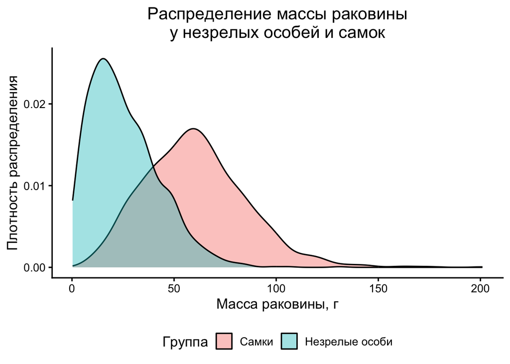

```r
ggplot(shell_data, aes(x = Shell_weight, fill = Sex)) +
  geom_density(alpha = 0.4) +
  scale_fill_manual(
    values = c("F" = "#CC79A7", "I" = "#DDCC77"),
    labels = c("F" = "Самки", "I" = "Незрелые")
  ) +
  scale_fill_discrete(
    labels = c("F" = "Самки", "I" = "Незрелые особи")
  ) +
  labs(
    title = "Распределение массы раковины\nу незрелых особей и самок",
    x = "Масса раковины, г",
    y = "Плотность распределения",
    fill = "Группа"
  ) +
  theme_classic(base_size = 14) +
  theme(
    plot.title = element_text(hjust = 0.5),
    legend.position = "bottom"
  )
```

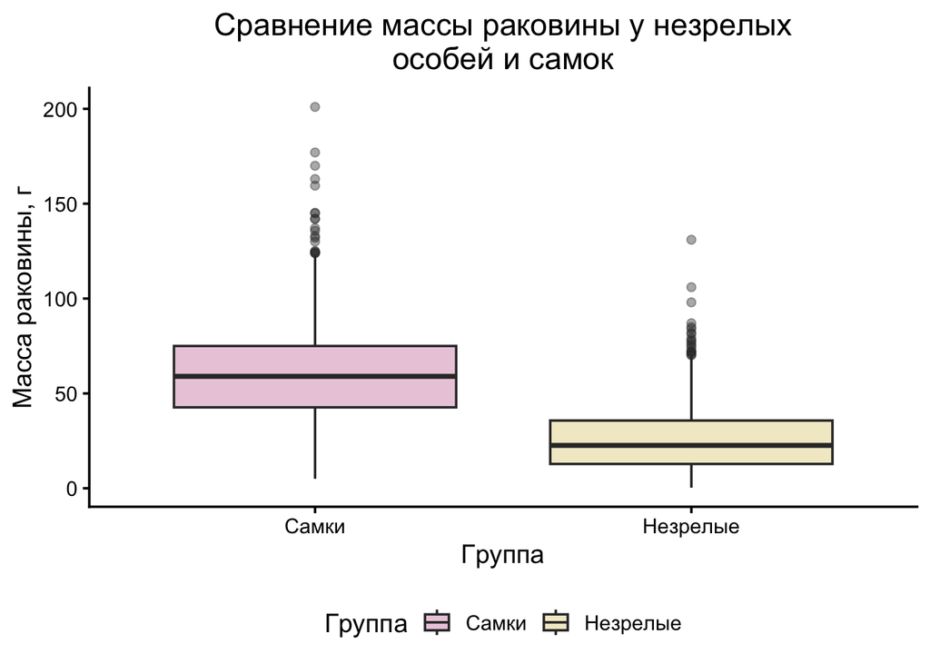

```r
ggplot(shell_data, aes(x = Sex, y = Shell_weight, fill = Sex)) +
  geom_boxplot(alpha = 0.4) +
  scale_fill_manual(
    values = c("F" = "#CC79A7", "I" = "#DDCC77"),
    labels = c("F" = "Самки", "I" = "Незрелые")
  ) +
  scale_x_discrete(
    labels = c("F" = "Самки", "I" = "Незрелые")
  ) +
  labs(
    title = "Сравнение массы раковины у незрелых\nособей и самок",
    x = "Группа",
    y = "Масса раковины, г",
    fill = "Группа"
  ) +
  theme_classic(base_size = 14) +
  theme(
    plot.title = element_text(hjust = 0.5),
    legend.position = "bottom"
  )
```

Распределение массы раковины у незрелых особей смещено влево, с небольшим хвостом вправо, и заметно меньше чем у самок. Распределение у самок колокообразно. Есть перекрытие примерно половины значений. ……

### Задание 3.3

Выберите подходящий статистический критерий. Самостоятельно рассчитайте его наблюдаемую статистику и необходимые критические значения при заданном уровне значимости. Укажите критическую область.

Не используйте функции, выполняющие готовую проверку гипотез. Функции для вычисления квантилей распределений использовать можно. Вычислять p-значение в этом задании не нужно.

```r
alpha <- 0.05

x <- shell_data$Shell_weight[shell_data$Sex == "I"]
y <- shell_data$Shell_weight[shell_data$Sex == "F"]

n_I <- length(x)
n_F <- length(y)

mean_I <- mean(x)
mean_F <- mean(y)
var_I <- var(x)
var_F <- var(y)

se <- sqrt(var_I / n_I + var_F / n_F)

t_obs <- (mean_I - mean_F) / se # Наблюдаемая статистика t-теста Уэлча

df <- (var_I / n_I + var_F / n_F)^2 / ((var_I / n_I)^2 / (n_I - 1) + (var_F / n_F)^2 / (n_F - 1)) # Число степеней свободы по формуле Уэлча — Саттертуэйта

t_crit <- qt(alpha, df = df) # Критическое значение для одностороннего теста - левостороннего

results <- data.frame(
  Показатель = c(
    "Среднее у незрелых особей",
    "Среднее у самок",
    "Наблюдаемая статистика",
    "Число степеней свободы",
    "Критическое значение",
    "Критическая область"
  ),
  Значение = c(
    mean_I,
    mean_F,
    t_obs,
    df,
    t_crit,
    paste0("(-Inf; ", round(t_crit, 4), ")")
  )
)

knitr::kable(
  results,
  digits = 3,
  caption = "Результаты расчёта t-критерия Уэлча"
)
```

Результаты расчёта t-критерия Уэлча

| Показатель | Значение |
| --- | --- |
| Среднее у незрелых особей | 25.6364381520119 |
| Среднее у самок | 60.4019892884468 |
| Наблюдаемая статистика | -41.6077691282546 |
| Число степеней свободы | 2285.98412395239 |
| Критическое значение | -1.64552046911595 |
| Критическая область | (-Inf; -1.6455) |

Наблюдаемая т-статистика меньше критического значения, поэтому с уровнем значимости 0,05 можем отвергнуть нулевую гипотезу, то есть масса раковин незрелых особей в среднем меньше, чем у самок ……

### Задание 3.4

На основании полученных результатов сформулируйте вывод относительно нулевой гипотезы и обоснуйте своё решение. Поддерживают ли данные предположение исследователей?

Наблюдаемая статистика (-41.6077691282546) попадает под критическую область (-Inf; -1.6455), потому с уровнем значимости 0,05 мы можем отвергнуть нулевую гипотезу. Полученные данные поддерживают предположение исследователей. ……

Что можно сказать о направлении и величине различия? Совпадает ли результат с вашим впечатлением от графика в задании 3.2? Как вы думаете, почему?

Результат согласуется с предположением, выдвинутым при анализе графика. Стат критерий подтверждает, что наблюдаемое различие средних статистически значимо и маловероятно получилось случайно ……